# Ex. 03-2: Finding motifs in ChIP-seq peaks

## 1. Finding motifs in a TF ChIP-seq peak set

### MEME suite

MEME is a suite of tools designed to identify, map and compare short motifs enriched in DNA sequences.  
It is particularly well-fitted for analysis of transcription factor binding sites. Many TFs have protein domains that specifically recognize a particular DNA sequence, based on their folding.

Have a look at MEME homepage:

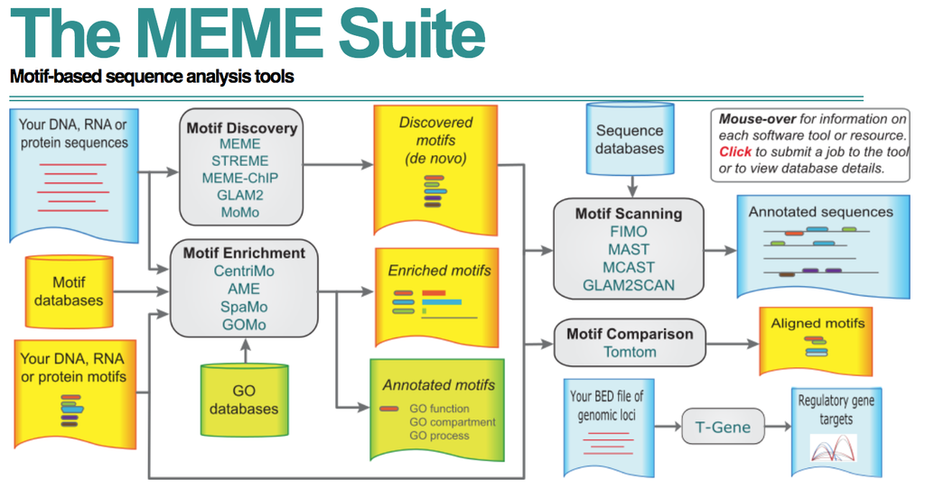

> Which tool do you think will be useful for us?

For an extensive of MEME internal computation steps, you can read the excellent in-depth presentation from Jonas Ibn-Salem [here](http://cbdm-01.zdv.uni-mainz.de/~jibnsale/teaching/SS16_MotifAnalysis_lecture_v02.pdf)

### Running MEME to find *de novo* motifs in Reb1 peaks

Let’s run MEME on peaks mapped in Reb1 ChIP-seq assay.

```bash
genome='Share/day03/results/genome/genome.fa'
peaks_folder='Share/day03/results/bwa/mergedLibrary/macs/narrowPeak/'
TF='Reb1_R1'
fasta_path="${TF}.fa"
output_dir="meme_out/${TF}"
mode='zoops'
nmotifs=2
min_width=6
max_width=15
#
bedtools getfasta -fi ${genome} -bed ${peaks_folder}/${TF}_peaks.narrowPeak > ${fasta_path}
mkdir meme_out/
meme \
    ${fasta_path} \
    -oc ${output_dir} \
    -searchsize 0 \
    -mod ${mode} \
    -nmotifs ${nmotifs} \
    -minw ${min_width} \
    -maxw ${max_width} \
    -V
```

> While the motif *de novo* search is running, have a look at [MEME website](http://meme-suite.org/).

> What is the purpose of each argument here?

> Have a look at the output. What are the identified motifs? Do they match published results? Where are they located in the MACS2 peaks?

> Can we avoid getting complementary motifs?

Check meme options with meme –help

```bash
output_dir="meme_out/${TF}_revcomp"
meme \
    ${fasta_path} \
    -oc ${output_dir} \
    -searchsize 0 \
    -mod ${mode} \
    -nmotifs ${nmotifs} \
    -minw ${min_width} \
    -maxw ${max_width} \
    -revcomp \
    -dna \
    -V
```

> What happened to the original two motifs? What can you conclude about Reb1 binding to the DNA?

> Do you find other interesting motifs?

> What is the proportion of peaks which contain the putative Reb1 binding motif? Was Reb1 supposed to be a particularly successful ChIP-seq experiment, according to MultiQC reports? What can you conclude about the meaning of a “bad quality” ChIP-seq library?

### Running STREME to find *de novo* motifs in Reb1 peaks

STREME is a newer tool in MEME ecosystem. It is faster, more sensitive and its documentation is clearer/simpler than original `meme`. It alleviates the need to specify a cumbersome list of obscure parameters.  
Let’s have a go at it.

```bash
genome='Share/day03/results/genome/genome.fa'
peaks_folder='Share/day03/results/bwa/mergedLibrary/macs/narrowPeak/'
TF='Reb1_R1'
fasta_path="${TF}.fa"
nmotifs=5
min_width=6
max_width=20
#
bedtools getfasta -fi ${genome} -bed ${peaks_folder}/${TF}_peaks.narrowPeak > ${fasta_path}
mkdir streme_out/
output_dir="streme_out/${TF}"
streme \
    --p ${fasta_path} \
    --oc ${output_dir} \
    --nmotifs ${nmotifs} \
    --minw ${min_width} \
    --maxw ${max_width}
```

> Compare STREME and MEME outputs for Reb1_R1. What do you think?

> Timewhise, how long did each command take to execute, roughly? How many peaks were analyzed in this example? And how many peaks other TF ChIP-seq libraries have in average? Comment.

### Running STREME to find *de novo* motifs for all TFs

*De novo* motif analyses were conducted with `Streme` for all the ChIP-seq libraries sequenced. We can use a `for` loop in Bash, as shown in this gist:

```bash
genome='Share/day03/results/genome/genome.fa'
peaks_folder='Share/day03/results/bwa/mergedLibrary/macs/narrowPeak/'
nmotifs=5
min_width=6
max_width=20
#
TFs=$(ls ${peaks_folder}*.narrowPeak | sed 's,_peaks.narrowPeak,,' | sed 's,.*/,,g')
for TF in ${TFs}
do
    echo -e "\033[0;31m[`date +"%T"`]\033[0;37m Processing ${TF} TF..."
    fasta_path="${peaks_folder}/${TF}_peaks.narrowPeak.fa"
    peaks="${peaks_folder}/${TF}_peaks.narrowPeak"
    output_dir="streme_out/${TF}"
    bedtools getfasta -fi ${genome} -bed ${peaks} > ${fasta_path}
    streme \
        --p ${fasta_path} \
        --oc ${output_dir} \
        --nmotifs ${nmotifs} \
        --minw ${min_width} \
        --maxw ${max_width} \
        --verbosity 1
done
```

> Check out the gist hereabove. Do you understand all the parameters? Is there a reason for increasing nmotifs? What about min_width/max_width?

> What can you say about the robustness of *de novo* motif analyses? Are they sensitive to ChIP-seq biological replicates? How would you deal with replicates in such case?

> Have a look at the motifs found enriched in peaks for each TF. Can you find motifs shared amongst multiple TFs?

## 2. Mapping site location relative to TSSs in the genome

### Importing MACS2 peaks in R

To deal with peak annotations, we can import them in R using the `rtracklayer` package. `rtracklayer` is one of the corner stones of the `R/Bioconductor` ecosystem. It allows to seamlessly import/export binarized or human-readable data, in or out of R, in most of the common genomic file formats.

```r
Reb1_peaks <- rtracklayer::import('Share/day03/results/bwa/mergedLibrary/macs/narrowPeak/Reb1_R1_peaks.narrowPeak')
```

> How many peaks were found in the Reb1 ChIP-seq library?

```r
length(Reb1_peaks)
```

```
## [1] 369
```

> What is the distribution of peak widths?

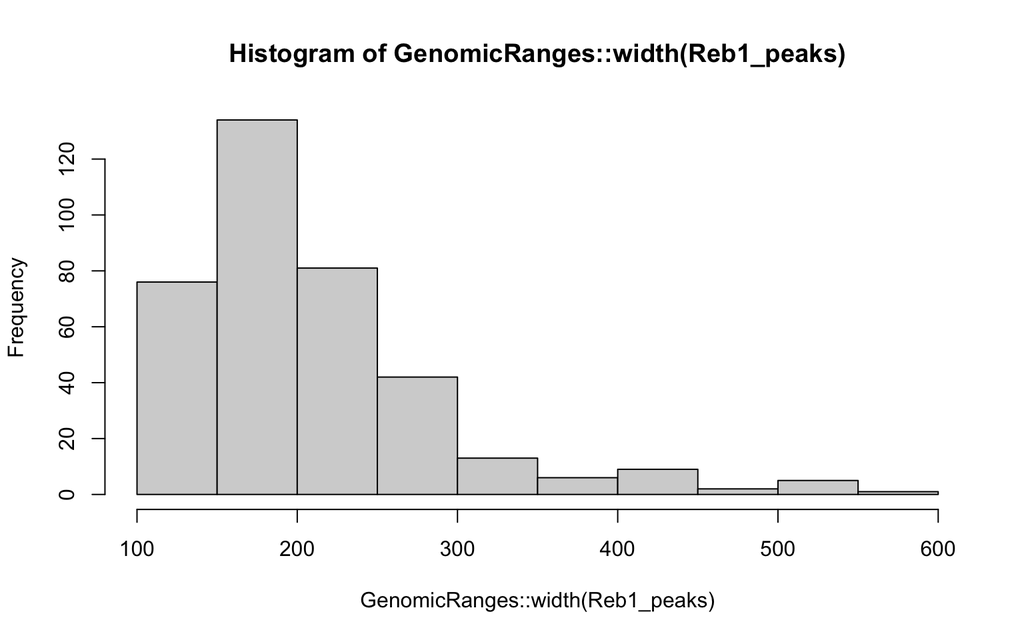

```r
hist(GenomicRanges::width(Reb1_peaks))
```

> Where is the peak summit located within each peak?

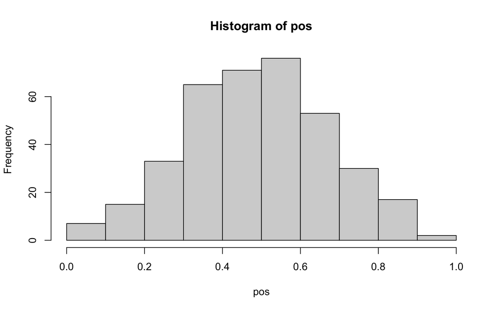

```r
Reb1_peak_summits <- rtracklayer::import('Share/day03/results/bwa/mergedLibrary/macs/narrowPeak/Reb1_R1_summits.bed')
pos <- {GenomicRanges::end(Reb1_peak_summits) - GenomicRanges::start(Reb1_peaks)} / {GenomicRanges::end(Reb1_peaks) - GenomicRanges::start(Reb1_peaks)}
hist(pos)
```

### Importing MEME motifs in R

Another task would be to import Probability Weight Matrices (PWMs) computed by by MEME.  
To do so, we can leverage several packages:

- `Biostrings` package is used to recover the entire Yeast genomic sequence.
- `universalmotif` is used to import STREME (or MEME) `.txt` output as PWMs.
- `TFBSTools` is used to map a PWM of interest on a entire genome sequence.

> Let’s import Reb1 and Abf1 motif PWMs and map their binding sites found in the genome.

```r
`%over%` <- IRanges::`%over%`
yeast_sequences <- Biostrings::readDNAStringSet('Share/day03/results/genome/genome.fa')
yeast_sequences
```

```
## DNAStringSet object of length 17:
##        width seq                                            names
##  [1]  230218 CCACACCACACCCACACACCCA...TGTGGGTGTGGTGTGTGTGGG I
##  [2]  813184 AAATAGCCCTCATGTACGTCTC...GGGTGTGGTGTGTGGGTGTGT II
##  [3]  316620 CCCACACACCACACCCACACCA...GTGGTGGGTGTGGTGTGTGTG III
##  [4] 1531933 ACACCACACCCACACCACACCC...AAGGTAGTAAGTAGCTTTTGG IV
##  [5]  439888 CACACACACCACACCCACACCA...ATGTGGGTGTGGTGTGTGTGT IX
##  ...     ... ...
## [13] 1078177 CACACACACACACCACCCACAC...AGACGTACATGAGGGCTATTT XII
## [14]  924431 CCACACACACACCACACCCACA...GGGTGTGGTGTGTGTGTGGGG XIII
## [15]  784333 CCGGCTTTCTGACCGAAATTAA...GTGTGTGGGTGTGGTGTGGGT XIV
## [16] 1091291 ACACCACACCCACACCACACCC...GAGTGTGTGGGTGTGGTGTGT XV
## [17]  948066 AAATAGCCCTCATGTACGTCTC...TTTTTTAATTTCGGTCAGAAA XVI
```

```r
Reb1_motifs <- universalmotif::read_meme('Share/day03/streme_out/Reb1_R1/streme.txt')
Reb1_PWM <- TFBSTools::PWMatrix(ID = 'Reb1', profileMatrix = Reb1_motifs[[1]]@motif)
Reb1_hits <- GenomicRanges::GRanges(
    TFBSTools::searchSeq(
        Reb1_PWM,
        yeast_sequences,
        strand = '*',
        min.score = '60%'
    )
)
Reb1_hits <- Reb1_hits[order(Reb1_hits$relScore, decreasing = TRUE)]
Reb1_hits
```

```
## GRanges object with 311133 ranges and 8 metadata columns:
##            seqnames        ranges strand | source feature  absScore  relScore
##               <Rle>     <IRanges>  <Rle> |  <Rle>   <Rle> <numeric> <numeric>
##        [1]       II 532371-532383      - |   TFBS    TFBS   9.31717   0.98392
##        [2]      VII 609251-609263      - |   TFBS    TFBS   9.31717   0.98392
##        [3]        X 615322-615334      + |   TFBS    TFBS   9.31717   0.98392
##        [4]        X 683628-683640      + |   TFBS    TFBS   9.31717   0.98392
##        [5]      XVI 614662-614674      + |   TFBS    TFBS   9.31717   0.98392
##        ...      ...           ...    ... .    ...     ...       ...       ...
##   [311129]      XVI 832139-832151      + |   TFBS    TFBS   5.89852  0.600056
##   [311130]     XIII 779274-779286      - |   TFBS    TFBS   5.89846  0.600050
##   [311131]      VII 272199-272211      + |   TFBS    TFBS   5.89846  0.600050
##   [311132]      VII   97518-97530      - |   TFBS    TFBS   5.89846  0.600050
##   [311133]      VII 905473-905485      - |   TFBS    TFBS   5.89840  0.600043
##               ID      TF   class       siteSeqs
##            <Rle>   <Rle>   <Rle> <DNAStringSet>
##        [1]  Reb1 Unknown Unknown  TATTACCCGGATT
##        [2]  Reb1 Unknown Unknown  TATTACCCGGATT
##        [3]  Reb1 Unknown Unknown  TATTACCCGGATT
##        [4]  Reb1 Unknown Unknown  TATTACCCGGATT
##        [5]  Reb1 Unknown Unknown  TATTACCCGGATT
##        ...   ...     ...     ...            ...
##   [311129]  Reb1 Unknown Unknown  CCGCACCCAGACC
##   [311130]  Reb1 Unknown Unknown  GGCTACGCCGCGC
##   [311131]  Reb1 Unknown Unknown  CGGTAGCGGGCCG
##   [311132]  Reb1 Unknown Unknown  GCTGCCCCGCGTC
##   [311133]  Reb1 Unknown Unknown  CGCTCCGCGGCCG
##   -------
##   seqinfo: 17 sequences from an unspecified genome; no seqlengths
```

```r
Reb1_hits <- Reb1_hits[Reb1_hits$relScore >= 0.80]
Reb1_hits
```

```
## GRanges object with 3642 ranges and 8 metadata columns:
##          seqnames          ranges strand | source feature  absScore  relScore
##             <Rle>       <IRanges>  <Rle> |  <Rle>   <Rle> <numeric> <numeric>
##      [1]       II   532371-532383      - |   TFBS    TFBS   9.31717   0.98392
##      [2]      VII   609251-609263      - |   TFBS    TFBS   9.31717   0.98392
##      [3]        X   615322-615334      + |   TFBS    TFBS   9.31717   0.98392
##      [4]        X   683628-683640      + |   TFBS    TFBS   9.31717   0.98392
##      [5]      XVI   614662-614674      + |   TFBS    TFBS   9.31717   0.98392
##      ...      ...             ...    ... .    ...     ...       ...       ...
##   [3638]       IV 1486389-1486401      - |   TFBS    TFBS   7.68117  0.800222
##   [3639]       XI   127163-127175      + |   TFBS    TFBS   7.68117  0.800222
##   [3640]      XII   300312-300324      + |   TFBS    TFBS   7.68111  0.800215
##   [3641]     XIII   413580-413592      + |   TFBS    TFBS   7.68106  0.800209
##   [3642]        I     59229-59241      - |   TFBS    TFBS   7.68106  0.800209
##             ID      TF   class       siteSeqs
##          <Rle>   <Rle>   <Rle> <DNAStringSet>
##      [1]  Reb1 Unknown Unknown  TATTACCCGGATT
##      [2]  Reb1 Unknown Unknown  TATTACCCGGATT
##      [3]  Reb1 Unknown Unknown  TATTACCCGGATT
##      [4]  Reb1 Unknown Unknown  TATTACCCGGATT
##      [5]  Reb1 Unknown Unknown  TATTACCCGGATT
##      ...   ...     ...     ...            ...
##   [3638]  Reb1 Unknown Unknown  GCTTACCCCCATT
##   [3639]  Reb1 Unknown Unknown  TGTAACCCTGCCA
##   [3640]  Reb1 Unknown Unknown  CGTTTCCCGGTCA
##   [3641]  Reb1 Unknown Unknown  GCTTACCCAGCCC
##   [3642]  Reb1 Unknown Unknown  TACTACCCGGGCC
##   -------
##   seqinfo: 17 sequences from an unspecified genome; no seqlengths
```

```r
Abf1_motifs <- universalmotif::read_meme('Share/day03/streme_out/Abf1_R1/streme.txt')
Abf1_PWM <- TFBSTools::PWMatrix(ID = 'Abf1', profileMatrix = Abf1_motifs[[1]]@motif)
Abf1_hits <- GenomicRanges::GRanges(
    TFBSTools::searchSeq(
        Abf1_PWM,
        yeast_sequences,
        strand = '*',
        min.score = '60%'
    )
)
Abf1_hits <- Abf1_hits[order(Abf1_hits$relScore, decreasing = TRUE)]
Abf1_hits
```

```
## GRanges object with 435578 ranges and 8 metadata columns:
##            seqnames          ranges strand | source feature  absScore  relScore
##               <Rle>       <IRanges>  <Rle> |  <Rle>   <Rle> <numeric> <numeric>
##        [1]       VI     40308-40321      - |   TFBS    TFBS   9.91774  1.000000
##        [2]      XIV   405788-405801      + |   TFBS    TFBS   9.90828  0.998973
##        [3]      VII   859686-859699      - |   TFBS    TFBS   9.88786  0.996754
##        [4]      VII   996717-996730      + |   TFBS    TFBS   9.87840  0.995727
##        [5]       II   770735-770748      - |   TFBS    TFBS   9.86923  0.994731
##        ...      ...             ...    ... .    ...     ...       ...       ...
##   [435574]       II   265820-265833      - |   TFBS    TFBS   6.23496  0.600001
##   [435575]       XV   932855-932868      - |   TFBS    TFBS   6.23496  0.600001
##   [435576]       IX     43651-43664      + |   TFBS    TFBS   6.23496  0.600001
##   [435577]       IV 1511267-1511280      + |   TFBS    TFBS   6.23496  0.600001
##   [435578]      XIV   748021-748034      - |   TFBS    TFBS   6.23495  0.600000
##               ID      TF   class       siteSeqs
##            <Rle>   <Rle>   <Rle> <DNAStringSet>
##        [1]  Abf1 Unknown Unknown TATCACTATACACG
##        [2]  Abf1 Unknown Unknown TATCACTATATACG
##        [3]  Abf1 Unknown Unknown TATCATTATACACG
##        [4]  Abf1 Unknown Unknown TATCATTATATACG
##        [5]  Abf1 Unknown Unknown TATCACTTTACACG
##        ...   ...     ...     ...            ...
##   [435574]  Abf1 Unknown Unknown GGTAGCTATGCATG
##   [435575]  Abf1 Unknown Unknown TGGCATTATCCCAG
##   [435576]  Abf1 Unknown Unknown CTTGAGTATTGCCG
##   [435577]  Abf1 Unknown Unknown ATGCATTTCGTCCG
##   [435578]  Abf1 Unknown Unknown TGCCAACATGCAAG
##   -------
##   seqinfo: 17 sequences from an unspecified genome; no seqlengths
```

```r
Abf1_hits <- Abf1_hits[Abf1_hits$relScore >= 0.80]
Abf1_hits
```

```
## GRanges object with 5442 ranges and 8 metadata columns:
##          seqnames        ranges strand | source feature  absScore  relScore
##             <Rle>     <IRanges>  <Rle> |  <Rle>   <Rle> <numeric> <numeric>
##      [1]       VI   40308-40321      - |   TFBS    TFBS   9.91774  1.000000
##      [2]      XIV 405788-405801      + |   TFBS    TFBS   9.90828  0.998973
##      [3]      VII 859686-859699      - |   TFBS    TFBS   9.88786  0.996754
##      [4]      VII 996717-996730      + |   TFBS    TFBS   9.87840  0.995727
##      [5]       II 770735-770748      - |   TFBS    TFBS   9.86923  0.994731
##      ...      ...           ...    ... .    ...     ...       ...       ...
##   [5438]       XI 543369-543382      + |   TFBS    TFBS   8.07653  0.800019
##   [5439]       XV 559666-559679      - |   TFBS    TFBS   8.07653  0.800019
##   [5440]      XII 615489-615502      - |   TFBS    TFBS   8.07649  0.800015
##   [5441]     XIII 903934-903947      - |   TFBS    TFBS   8.07648  0.800015
##   [5442]       II 371072-371085      + |   TFBS    TFBS   8.07638  0.800004
##             ID      TF   class       siteSeqs
##          <Rle>   <Rle>   <Rle> <DNAStringSet>
##      [1]  Abf1 Unknown Unknown TATCACTATACACG
##      [2]  Abf1 Unknown Unknown TATCACTATATACG
##      [3]  Abf1 Unknown Unknown TATCATTATACACG
##      [4]  Abf1 Unknown Unknown TATCATTATATACG
##      [5]  Abf1 Unknown Unknown TATCACTTTACACG
##      ...   ...     ...     ...            ...
##   [5438]  Abf1 Unknown Unknown TATCATCTTTAAAG
##   [5439]  Abf1 Unknown Unknown TATCATCTTTAAAG
##   [5440]  Abf1 Unknown Unknown AATCACCATATATG
##   [5441]  Abf1 Unknown Unknown TATCATTCCAAAAG
##   [5442]  Abf1 Unknown Unknown TATCAAGAGCTACG
##   -------
##   seqinfo: 17 sequences from an unspecified genome; no seqlengths
```

> Compare the peaks found by MACS2 with the binding motifs found when mapping the STREME-derived PWMs onto the Yeast genome sequence. Are they overlapping? How far from the nearest motif each peak is?

```r
table(Reb1_hits %over% Reb1_peaks)
```

```
##
## FALSE  TRUE
##  3195   447
```

> Check the seqname nomenclature of the 2 GRanges objects with `seqlevelsStyle()`. Are they identical?

```r
GenomeInfoDb::seqlevelsStyle(Reb1_hits)
```

```
## [1] "NCBI"
```

```r
GenomeInfoDb::seqlevelsStyle(Reb1_peaks)
```

```
## [1] "NCBI"
```

```r
GenomeInfoDb::seqlevelsStyle(Reb1_hits) <- "NCBI"
table(Reb1_peaks %over% Reb1_hits)
```

```
##
## FALSE  TRUE
##    36   333
```

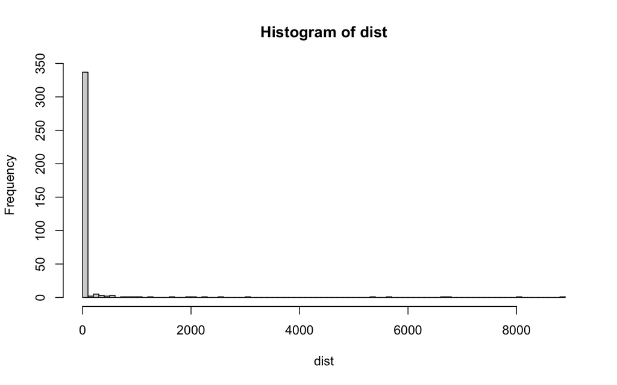

```r
dist <- GenomicRanges::distanceToNearest(Reb1_peaks, Reb1_hits)@elementMetadata$distance
hist(dist, breaks = 100)
```

```r
Abf1_peaks <- rtracklayer::import('Share/day03/results/bwa/mergedLibrary/macs/narrowPeak/Abf1_R1_peaks.narrowPeak')
GenomeInfoDb::seqlevelsStyle(Abf1_hits) <- "NCBI"
table(Abf1_peaks %over% Abf1_hits)
```

```
##
## FALSE  TRUE
##   761   555
```

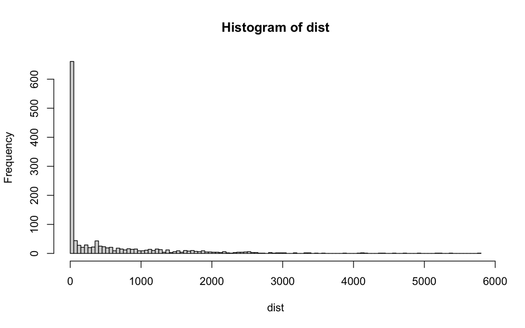

```r
dist <- GenomicRanges::distanceToNearest(Abf1_peaks, Abf1_hits)@elementMetadata$distance
hist(dist, breaks = 100)
```

> Compare the overlap of Abf1 and Rap1 peaks.

```r
Rap1_peaks <- rtracklayer::import('Share/day03/results/bwa/mergedLibrary/macs/narrowPeak/Rap1_R1_peaks.narrowPeak')
table(Abf1_peaks %over% Rap1_peaks)
```

```
##
## FALSE  TRUE
##  1102   214
```

## Conclusions

> How do PWM motif scanning and peak calling reconcile with each other? Which one provides a better estimation of the regions regulated by a given transcription factor?

> How could you compare overlaps of multiple sets of TF peaks in a more comprehensive way?